# section_4.1(Final)

```python
# Importing necessary packages
import numpy as np
import matplotlib.pyplot as plt
from astropy.io import fits
from astropy.modeling import models, fitting
```

numpy:

A library for numerical computing in Python. NumPy provides support for large, multi-dimensional arrays and matrices, along with a collection of mathematical functions to operate on these arrays. It's essential for handling pixel data in images.

matplotlib.pyplot:

Used for plotting and visualizing data. In this case, it will help generate histograms of the pixel values in the bias frames.

from astropy.io import fits:

Used for reading and writing FITS (Flexible Image Transport System) files. FITS is a standard format for storing astronomical data, such as images from telescopes.

from astropy.modeling import models, fitting:

These modules allow the createcreation of mathematical models and perform fitting (e.g., fitting a Gaussian model to a distribution). This will be useful later for fitting a Gaussian to the count distribution and calculating the read noise.

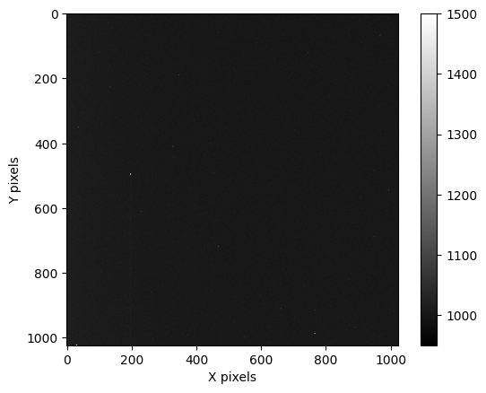

```python
#4.1.1
bias_frame=fits.open(r"../FITS_Files/3.1_bias.00000011.BIAS.FIT")
bias_frame_data=bias_frame[0].data
# Extracts the pixel data from the first HDU (Header/Data Unit) of the FITS file.
# The data is stored as a 2D array where each element represents a pixel's count value in the bias frame.
plt.imshow(bias_frame_data,cmap='gray',vmin=950,vmax=1500)
plt.colorbar()
plt.xlabel('X pixels')
plt.ylabel('Y pixels')
plt.show()
```

This cell of code opens a bias frame FITS file at 0°C using the Astropy library, extracting the pixel data into a 2D array. It visualizes the data using Matplotlib's `imshow()` function, with pixel intensity values ranging from 950 to 1500 to enhance the visibility of any variations, including potential hot pixels, which are indicated by bright spots in the image. A color bar is added for reference, and the axes are labeled to denote the pixel coordinates. The purpose of this image is for an initial visual assessment of the bias frame's pixel intensity distribution, to identify and reject hot pixels.

The image (bias frame) shows a largely uniform grayscale plot, indicating that most of the pixels have similar values. A few bright spots may represent hot pixels, which can be identified by their higher-than-usual pixel values. Further analysis will be in the histogram below.

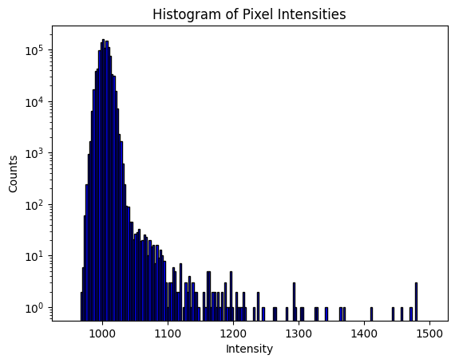

```python
flattened_data=bias_frame_data.flatten()
# Flattens the 2D array of pixel data (bias_frame_data) into a 1D array.
plt.hist(flattened_data,bins=200,range=(950,1500),log=True,color='blue',edgecolor='black')
plt.title('Histogram of Pixel Intensities')
plt.xlabel('Intensity')
plt.ylabel('Counts')
```

This is the histogram of the distribution of pixel intensities in the bias frame. The large peak around 1000 counts represents the bulk of the pixel values in the bias frame, which is expected for most pixels. The tail on the right-hand side represents hot pixels, where the pixel values deviate significantly from the bulk of the data. These hot pixels can be identified as outliers with much higher intensity values, and they are likely candidates for rejection in the analysis. The log scale makes it easier to spot both the large concentration of pixels around the peak and the outliers (hot pixels) in the tail.

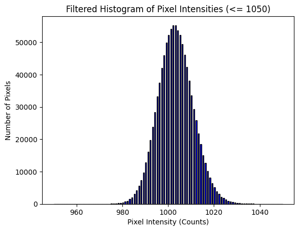

```python
def filter_and_plot_histogram(flattened_data, threshold=1050):
    """
    Filter the pixel intensity data, and plot a histogram of the filtered data.

    :param flattened_data: 1D array of pixel intensity values from the bias frame.
    :type flattened_data: np.ndarray
    :param threshold: Intensity threshold to filter the pixel values.
    :type threshold: int
    :return: Filtered data (1D array), Hot pixels (list of lists with [index, value]),
    Number of rejected pixels.
    :rtype: tuple(np.ndarray, list, int)
    """
    # Filtering the data to include only values less than or equal to the threshold
    filtered_data = flattened_data[flattened_data <= threshold]
    # Plotting the filtered histogram
    plt.hist(filtered_data, bins=200, range=(950, 1050), color='blue', edgecolor='black')
    plt.title('Filtered Histogram of Pixel Intensities (<= 1050)')
    plt.xlabel('Pixel Intensity (Counts)')
    plt.ylabel('Number of Pixels')
    plt.show()

    return filtered_data

# Call the function
filtered_data = filter_and_plot_histogram(flattened_data)
```

```python
num_cut_pixels=len(flattened_data)-len(filtered_data)

fraction_cut=(num_cut_pixels/len(flattened_data))*100

print(f'Number of pixels cut: {num_cut_pixels}')
print(f'Fraction of pixel cut: {fraction_cut}')
```

```
Number of pixels cut: 413
Fraction of pixel cut: 0.039386749267578125
```

This cell of code calculates the count of pixels that were excluded for exceeding the defined intensity threshold by subtracting the number of pixels in the filtered data from the total pixels in the flattened data.

There are 413 pixels removed from the dataset for exceeding the designated intensity threshold. This finding proves that we can use the method of calculating the difference between the original and filtered datasets. Importantly, this represents a mere 0.04% of the total pixel count in the bias frame, which means the effect of pixel saturation is negligible on the overall pixel distribution, indicating that most pixels adhere to the anticipated Gaussian distribution.

```python
# Section 4.1.2

mean_filtered=np.mean(filtered_data)
std_filtered=np.std(filtered_data)
# Computes the mean and standard deviation of the filtered data
print(f'Mean of the filtered data: {mean_filtered}')
print(f'Standard deviation of the filtered data:{std_filtered}')
```

```
Mean of the filtered data: 1002.9957325339666
Standard deviation of the filtered data:7.718023440399738
```

The mean of the filtered data is approximately 1002.996, indicating that the average pixel intensity after filtering is close to 1003, in the range with a maximum of 1050 counts. The standard deviation of about 7.718 suggests a relatively low level of noise in the pixel intensities, which is characteristic of a well-calibrated bias frame.

These data will be used to determine the read noise of the CCD in units of counts.

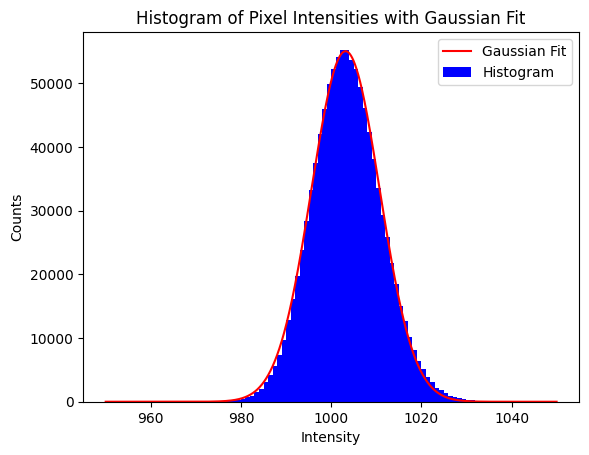

```python
def plot_gaussian(data, range_values, mean, stddev, num_bins):
    """
    Plot a histogram of the pixel intensities with an overlaid Gaussian fit.

    :param data: The pixel intensity data to plot.
    :type data: np.ndarray
    :param range_values: The range for the histogram (min, max).
    :type range_values: tuple
    :param mean: The mean of the Gaussian fit.
    :type mean: float :unit: Analog Digital Unit (ADU)
    :param stddev: The standard deviation of the Gaussian fit.
    :type stddev: float :unit: Analog Digital Unit (ADU)
    :param num_bins: The number of bins to use for the histogram.
    :type num_bins: int
    :return: Displays the plot with the histogram and Gaussian fit.
    :rtype: None
    """
    # Calculate histogram
    bin_heights, bin_borders = np.histogram(data, bins=num_bins, range=range_values)
    bin_widths = np.diff(bin_borders)
    bin_centers = bin_borders[:-1] + bin_widths / 2

    # Initialize Gaussian model
    gaussian = models.Gaussian1D(mean=mean, stddev=stddev)

    # Select fitting algorithm
    fitter = fitting.LevMarLSQFitter()

    # Fit the Gaussian model to the histogram data
    best_fit = fitter(gaussian, bin_centers, bin_heights)

    # Determine x-values for Gaussian fit
    x_interval_Gaussian = np.linspace(range_values[0], range_values[1], 10000)

    # Create the plot
    plt.figure()
    plt.bar(bin_centers, bin_heights, width=bin_widths, label='Histogram', log=False, color='blue')
    plt.plot(x_interval_Gaussian, best_fit(x_interval_Gaussian), label='Gaussian Fit', color='red')
    plt.xlabel('Intensity')
    plt.ylabel('Counts')
    plt.title('Histogram of Pixel Intensities with Gaussian Fit')
    plt.legend()
    plt.show()

# Example usage
plot_gaussian(data=filtered_data, range_values=(950, 1050), mean=np.mean(filtered_data), stddev=np.std(filtered_data), num_bins=100)
```

This function is designed to create a histogram of pixel intensities and overlay a Gaussian fit to visualize the distribution of pixel values in a dataset.

This function applied fitting techniques: Gaussian1D and LevMarLSQFitter, to achieve the desired curve fitting from the astropy.modeling package. The reason of using 100 bins instead of 200 is because it helps maintain a higher amplitude for the Gaussian curve relative to the histogram. A higher number of bins can be challenging for the histogram to stay in a good shape of Gaussian fit. This fragmentation diminishes the visibility of the peak in the Gaussian fit, makes the interpretation of the underlying data distribution harder.

```python
gain=2

actual_num_electrons=14.8

measured_num_electrons=gain*np.std(filtered_data)

difference=measured_num_electrons-actual_num_electrons
percentage_error= (difference/actual_num_electrons)*100

print(f'Measured number of electrons:{measured_num_electrons}e-')
print(f'Difference:{difference}e-')
print(f'Percentage error:{percentage_error}%')
```

```
Measured number of electrons:15.436046880799475e-
Difference:0.6360468807994746e-
Percentage error:4.297614059455909%
```

This part calculates the measured number of electrons associated with the read noise of a CCD camera and evaluates its accuracy against an expected value, begins by setting the gain of the camera to 2 and the actual number of electrons to 14.8. The measured electrons are then calculated by multiplying the gain with the standard deviation of the filtered pixel data. Subsequently, the code computes the difference between the measured and actual electron values, along with the percentage error to quantify the accuracy of the measurement. Finally, it outputs the measured number of electrons, the difference from the expected value, and the percentage error, enabling an assessment of the read noise consistency with the manufacturer’s specifications.